# maladie_cardiaque

**Made By DAHOU RENAUD L. Data Scientist in Benin**

- Whatsapp: +22967927952
- Email: dahou.r@yahoo.com

[figure not shown]

### A propos de la base de donnée

Cette base de données ([lien](https://www.kaggle.com/ronitf/heart-disease-uci)) contient 76 attributs, mais toutes les expériences publiées se réfèrent à l'utilisation d'un sous-ensemble de 14 d'entre eux. En particulier, la base de données de Cleveland est la seule qui ait été utilisée par les chercheurs de ML à ce jour. Le champ «objectif» fait référence à la présence d'une maladie cardiaque chez le patient. Il s'agit d'un entier valant de 0 (pas de présence) à 4.

Je vais donc explorer cette base de donné dans un premier temps et ensuite construire un modèle de **Machine learning** qui prédira si un individu est malade(1) ou non(0)

#### Informations sur les attributs:

> 1. âge (age)
> 2. sexe (sex)
> 3. type de douleur thoracique (4 valeurs) (cp)
> 4. pression artérielle au repos(trestbps)
> 5. cholestoral sérique en mg / dl (chol)
> 6. glycémie à jeun> 120 mg / dl (fbs)
> 7. résultats électrocardiographiques au repos (valeurs 0,1,2) (restecg)
> 8. fréquence cardiaque maximale atteinte(thalach)
> 9. angine de poitrineinduite par l'exercice (exang)
> 10. oldpeak = dépression ST induite par l'exercice par rapport au repos(oldpeak)
> 11. pente du segment ST maximal de l'exercice(slope) 12 nombre de vaisseaux principaux (0-3) colorés par une fluoroscopie(ca)
> 12. thal: 3 = normal; 6 = défaut fixe; 7 = défaut réversible '(thal)

### Connexion à notre répertoire

```python
from google.colab import drive
drive.mount('/content/drive/')
```

```python
#!jupyter nbconvert --to html maladie_cardiaque.ipynb
```

[output not shown]

```python
import os
os.chdir("/content/drive/My Drive/DATASCIENCE/Projet/Cleveland ")
```

```python
#load dataset
import pandas as pd
import warnings
warnings.filterwarnings('ignore')
df = pd.read_csv('Cleveland_hd.csv')
df
```

|  | age | sex | cp | trestbps | chol | fbs | restecg | thalach | exang | oldpeak | slope | ca | thal | class |
| --- | --- | --- | --- | --- | --- | --- | --- | --- | --- | --- | --- | --- | --- | --- |
| 0 | 63 | 1 | 1 | 145 | 233 | 1 | 2 | 150 | 0 | 2.3 | 3 | 0.0 | 6.0 | 0 |
| 1 | 67 | 1 | 4 | 160 | 286 | 0 | 2 | 108 | 1 | 1.5 | 2 | 3.0 | 3.0 | 2 |
| 2 | 67 | 1 | 4 | 120 | 229 | 0 | 2 | 129 | 1 | 2.6 | 2 | 2.0 | 7.0 | 1 |
| 3 | 37 | 1 | 3 | 130 | 250 | 0 | 0 | 187 | 0 | 3.5 | 3 | 0.0 | 3.0 | 0 |
| 4 | 41 | 0 | 2 | 130 | 204 | 0 | 2 | 172 | 0 | 1.4 | 1 | 0.0 | 3.0 | 0 |
| ... | ... | ... | ... | ... | ... | ... | ... | ... | ... | ... | ... | ... | ... | ... |
| 298 | 45 | 1 | 1 | 110 | 264 | 0 | 0 | 132 | 0 | 1.2 | 2 | 0.0 | 7.0 | 1 |
| 299 | 68 | 1 | 4 | 144 | 193 | 1 | 0 | 141 | 0 | 3.4 | 2 | 2.0 | 7.0 | 2 |
| 300 | 57 | 1 | 4 | 130 | 131 | 0 | 0 | 115 | 1 | 1.2 | 2 | 1.0 | 7.0 | 3 |
| 301 | 57 | 0 | 2 | 130 | 236 | 0 | 2 | 174 | 0 | 0.0 | 2 | 1.0 | 3.0 | 1 |
| 302 | 38 | 1 | 3 | 138 | 175 | 0 | 0 | 173 | 0 | 0.0 | 1 | NaN | 3.0 | 0 |

303 rows × 14 columns

### introduction de la cible dans la dataset

```python
#Convert two class names to 0 and 1
df['Target']= [0 if each == 0 else 1 for each in df['class']]
df
```

|  | age | sex | cp | trestbps | chol | fbs | restecg | thalach | exang | oldpeak | slope | ca | thal | class | Target |
| --- | --- | --- | --- | --- | --- | --- | --- | --- | --- | --- | --- | --- | --- | --- | --- |
| 0 | 63 | 1 | 1 | 145 | 233 | 1 | 2 | 150 | 0 | 2.3 | 3 | 0.0 | 6.0 | 0 | 0 |
| 1 | 67 | 1 | 4 | 160 | 286 | 0 | 2 | 108 | 1 | 1.5 | 2 | 3.0 | 3.0 | 2 | 1 |
| 2 | 67 | 1 | 4 | 120 | 229 | 0 | 2 | 129 | 1 | 2.6 | 2 | 2.0 | 7.0 | 1 | 1 |
| 3 | 37 | 1 | 3 | 130 | 250 | 0 | 0 | 187 | 0 | 3.5 | 3 | 0.0 | 3.0 | 0 | 0 |
| 4 | 41 | 0 | 2 | 130 | 204 | 0 | 2 | 172 | 0 | 1.4 | 1 | 0.0 | 3.0 | 0 | 0 |
| ... | ... | ... | ... | ... | ... | ... | ... | ... | ... | ... | ... | ... | ... | ... | ... |
| 298 | 45 | 1 | 1 | 110 | 264 | 0 | 0 | 132 | 0 | 1.2 | 2 | 0.0 | 7.0 | 1 | 1 |
| 299 | 68 | 1 | 4 | 144 | 193 | 1 | 0 | 141 | 0 | 3.4 | 2 | 2.0 | 7.0 | 2 | 1 |
| 300 | 57 | 1 | 4 | 130 | 131 | 0 | 0 | 115 | 1 | 1.2 | 2 | 1.0 | 7.0 | 3 | 1 |
| 301 | 57 | 0 | 2 | 130 | 236 | 0 | 2 | 174 | 0 | 0.0 | 2 | 1.0 | 3.0 | 1 | 1 |
| 302 | 38 | 1 | 3 | 138 | 175 | 0 | 0 | 173 | 0 | 0.0 | 1 | NaN | 3.0 | 0 | 0 |

303 rows × 15 columns

## **L'analyse exploratoire des données**

Tout d'abord, nous devons explorer notre ensemble de données. en cela, nous avons besoin de quelques données statistiques.

```python
df.info()
```

```
<class 'pandas.core.frame.DataFrame'>
RangeIndex: 303 entries, 0 to 302
Data columns (total 15 columns):
age         303 non-null int64
sex         303 non-null int64
cp          303 non-null int64
trestbps    303 non-null int64
chol        303 non-null int64
fbs         303 non-null int64
restecg     303 non-null int64
thalach     303 non-null int64
exang       303 non-null int64
oldpeak     303 non-null float64
slope       303 non-null int64
ca          299 non-null float64
thal        301 non-null float64
class       303 non-null int64
Target      303 non-null int64
dtypes: float64(3), int64(12)
memory usage: 35.6 KB
```

Nous constatons qu'il y a des données manquantes dans notre base de données au lieu de 303 entrée nous constatons une iregularité au niveau de ca et Thal.

```python
# Fonction pour calculer les valeurs manquantes par colonne# Funct
def missing_values_table(df):
        # Total des valeurs manquantes
        mis_val = df.isnull().sum()

        # Pourcentage des valeurs manquantes
        mis_val_percent = 100 * df.isnull().sum() / len(df)

        # Faire un tableau avec les résultats
        mis_val_table = pd.concat([mis_val, mis_val_percent], axis=1)

        # Renommez les colonnes
        mis_val_table_ren_columns = mis_val_table.rename(
        columns = {0 : 'Missing Values', 1 : '% of Total Values'})

        # Trier le tableau par pourcentage de manquant décroissant
        mis_val_table_ren_columns = mis_val_table_ren_columns[
            mis_val_table_ren_columns.iloc[:,1] != 0].sort_values(
        '% of Total Values', ascending=False).round(1)
        # Imprimer quelques informations sommaires
        print ("Your selected dataframe has " + str(df.shape[1]) + " columns.\n"
            "There are " + str(mis_val_table_ren_columns.shape[0]) +
              " columns that have missing values.")

        # Renvoie le dataframe avec les informations manquantes
        return mis_val_table_ren_columns
```

```python
# Statistiques sur les valeurs manquantes
missing_values = missing_values_table(df)
missing_values.head(20)
```

```
Your selected dataframe has 15 columns.
There are 2 columns that have missing values.
```

|  | Missing Values | % of Total Values |
| --- | --- | --- |
| ca | 4 | 1.3 |
| thal | 2 | 0.7 |

il y a très peu de valeur manquante dans notre base de données comme on peut le constater. nous choisissons de les supprimer

```python
df=df.dropna()
df
```

|  | age | sex | cp | trestbps | chol | fbs | restecg | thalach | exang | oldpeak | slope | ca | thal | class | Target |
| --- | --- | --- | --- | --- | --- | --- | --- | --- | --- | --- | --- | --- | --- | --- | --- |
| 0 | 63 | 1 | 1 | 145 | 233 | 1 | 2 | 150 | 0 | 2.3 | 3 | 0.0 | 6.0 | 0 | 0 |
| 1 | 67 | 1 | 4 | 160 | 286 | 0 | 2 | 108 | 1 | 1.5 | 2 | 3.0 | 3.0 | 2 | 1 |
| 2 | 67 | 1 | 4 | 120 | 229 | 0 | 2 | 129 | 1 | 2.6 | 2 | 2.0 | 7.0 | 1 | 1 |
| 3 | 37 | 1 | 3 | 130 | 250 | 0 | 0 | 187 | 0 | 3.5 | 3 | 0.0 | 3.0 | 0 | 0 |
| 4 | 41 | 0 | 2 | 130 | 204 | 0 | 2 | 172 | 0 | 1.4 | 1 | 0.0 | 3.0 | 0 | 0 |
| ... | ... | ... | ... | ... | ... | ... | ... | ... | ... | ... | ... | ... | ... | ... | ... |
| 297 | 57 | 0 | 4 | 140 | 241 | 0 | 0 | 123 | 1 | 0.2 | 2 | 0.0 | 7.0 | 1 | 1 |
| 298 | 45 | 1 | 1 | 110 | 264 | 0 | 0 | 132 | 0 | 1.2 | 2 | 0.0 | 7.0 | 1 | 1 |
| 299 | 68 | 1 | 4 | 144 | 193 | 1 | 0 | 141 | 0 | 3.4 | 2 | 2.0 | 7.0 | 2 | 1 |
| 300 | 57 | 1 | 4 | 130 | 131 | 0 | 0 | 115 | 1 | 1.2 | 2 | 1.0 | 7.0 | 3 | 1 |
| 301 | 57 | 0 | 2 | 130 | 236 | 0 | 2 | 174 | 0 | 0.0 | 2 | 1.0 | 3.0 | 1 | 1 |

297 rows × 15 columns

Nous passons de 303 lignes à 297 ligne

### statistique descriptive

```python
df.describe()
```

|  | age | sex | cp | trestbps | chol | fbs | restecg | thalach | exang | oldpeak | slope | ca | thal | class | Target |
| --- | --- | --- | --- | --- | --- | --- | --- | --- | --- | --- | --- | --- | --- | --- | --- |
| count | 297.000000 | 297.000000 | 297.000000 | 297.000000 | 297.000000 | 297.000000 | 297.000000 | 297.000000 | 297.000000 | 297.000000 | 297.000000 | 297.000000 | 297.000000 | 297.000000 | 297.000000 |
| mean | 54.542088 | 0.676768 | 3.158249 | 131.693603 | 247.350168 | 0.144781 | 0.996633 | 149.599327 | 0.326599 | 1.055556 | 1.602694 | 0.676768 | 4.730640 | 0.946128 | 0.461279 |
| std | 9.049736 | 0.468500 | 0.964859 | 17.762806 | 51.997583 | 0.352474 | 0.994914 | 22.941562 | 0.469761 | 1.166123 | 0.618187 | 0.938965 | 1.938629 | 1.234551 | 0.499340 |
| min | 29.000000 | 0.000000 | 1.000000 | 94.000000 | 126.000000 | 0.000000 | 0.000000 | 71.000000 | 0.000000 | 0.000000 | 1.000000 | 0.000000 | 3.000000 | 0.000000 | 0.000000 |
| 25% | 48.000000 | 0.000000 | 3.000000 | 120.000000 | 211.000000 | 0.000000 | 0.000000 | 133.000000 | 0.000000 | 0.000000 | 1.000000 | 0.000000 | 3.000000 | 0.000000 | 0.000000 |
| 50% | 56.000000 | 1.000000 | 3.000000 | 130.000000 | 243.000000 | 0.000000 | 1.000000 | 153.000000 | 0.000000 | 0.800000 | 2.000000 | 0.000000 | 3.000000 | 0.000000 | 0.000000 |
| 75% | 61.000000 | 1.000000 | 4.000000 | 140.000000 | 276.000000 | 0.000000 | 2.000000 | 166.000000 | 1.000000 | 1.600000 | 2.000000 | 1.000000 | 7.000000 | 2.000000 | 1.000000 |
| max | 77.000000 | 1.000000 | 4.000000 | 200.000000 | 564.000000 | 1.000000 | 2.000000 | 202.000000 | 1.000000 | 6.200000 | 3.000000 | 3.000000 | 7.000000 | 4.000000 | 1.000000 |

nous pouvons constater que la population étudier à un age compris entre 29 ans et 77ans

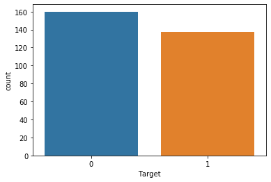

```python
import seaborn as sns
sns.countplot(x="Target", data=df)
```

Nous avons plus d'individu non malade que malade

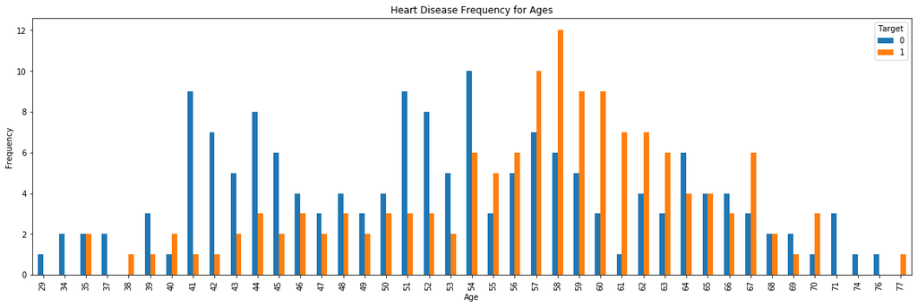

```python
import matplotlib.pyplot as plt

pd.crosstab(df.age,df['Target']).plot(kind="bar",figsize=(20,6))
plt.title('Heart Disease Frequency for Ages')
plt.xlabel('Age')
plt.ylabel('Frequency')
plt.savefig('heartDiseaseAndAges.png')
plt.show()
```

Créons un intervalle d'âge pour voir les tranches qui sont les plus risquées pour contracter une maladie cardiaque

```python
df['ageint']=pd.cut(df.age, bins=[ 25, 40, 55, 70, 85], labels=['A', 'B', 'C', 'D'])
df
```

|  | age | sex | cp | trestbps | chol | fbs | restecg | thalach | exang | oldpeak | slope | ca | thal | class | Target | ageint |
| --- | --- | --- | --- | --- | --- | --- | --- | --- | --- | --- | --- | --- | --- | --- | --- | --- |
| 0 | 63 | 1 | 1 | 145 | 233 | 1 | 2 | 150 | 0 | 2.3 | 3 | 0.0 | 6.0 | 0 | 0 | C |
| 1 | 67 | 1 | 4 | 160 | 286 | 0 | 2 | 108 | 1 | 1.5 | 2 | 3.0 | 3.0 | 2 | 1 | C |
| 2 | 67 | 1 | 4 | 120 | 229 | 0 | 2 | 129 | 1 | 2.6 | 2 | 2.0 | 7.0 | 1 | 1 | C |
| 3 | 37 | 1 | 3 | 130 | 250 | 0 | 0 | 187 | 0 | 3.5 | 3 | 0.0 | 3.0 | 0 | 0 | A |
| 4 | 41 | 0 | 2 | 130 | 204 | 0 | 2 | 172 | 0 | 1.4 | 1 | 0.0 | 3.0 | 0 | 0 | B |
| ... | ... | ... | ... | ... | ... | ... | ... | ... | ... | ... | ... | ... | ... | ... | ... | ... |
| 297 | 57 | 0 | 4 | 140 | 241 | 0 | 0 | 123 | 1 | 0.2 | 2 | 0.0 | 7.0 | 1 | 1 | C |
| 298 | 45 | 1 | 1 | 110 | 264 | 0 | 0 | 132 | 0 | 1.2 | 2 | 0.0 | 7.0 | 1 | 1 | B |
| 299 | 68 | 1 | 4 | 144 | 193 | 1 | 0 | 141 | 0 | 3.4 | 2 | 2.0 | 7.0 | 2 | 1 | C |
| 300 | 57 | 1 | 4 | 130 | 131 | 0 | 0 | 115 | 1 | 1.2 | 2 | 1.0 | 7.0 | 3 | 1 | C |
| 301 | 57 | 0 | 2 | 130 | 236 | 0 | 2 | 174 | 0 | 0.0 | 2 | 1.0 | 3.0 | 1 | 1 | C |

297 rows × 16 columns

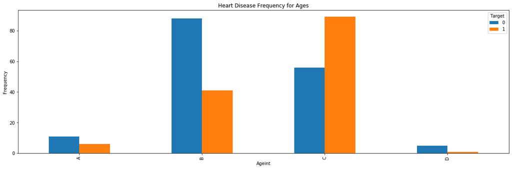

```python
pd.crosstab(df.ageint,df['Target']).plot(kind="bar",figsize=(20,6))
plt.title('Heart Disease Frequency for Ages')
plt.xlabel('Ageint')
plt.ylabel('Frequency')
plt.savefig('heartDiseaseAndAges.png')
plt.show()
```

Nous pouvons constater que les sous-populations les plus malade sont les personnes dont l'âge se situe entre [55-70[ en premier et [40-55[ en second. Tandis que celle entre [25-40[ et celle entre [70-85] sont les moins malades.

**La question qu'on peut se poser est que est-ce qu'il existe réellement un lien fort entre l'âge et la maladie cardiaque développé?** L'analyse de corrélation nous en dira plus

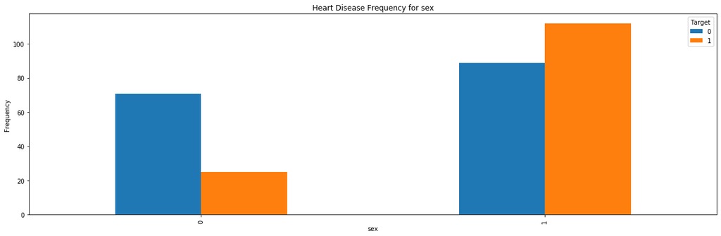

```python
pd.crosstab(df.sex,df['Target']).plot(kind="bar",figsize=(20,6))
plt.title('Heart Disease Frequency for sex')
plt.xlabel('sex')
plt.ylabel('Frequency')
plt.savefig('heartDiseaseAndAges.png')
plt.show()
```

Les hommes sont les plus exposés aux maladie cardiaque

**La question qu'on peut se poser est qu'est-ce qu'il existe réellement un lien fort entre sex et le type de maladie cardiaque développé?** L'analyse de corrélation nous en dira plus

### Analyse de correlation

```python
import numpy as np

corre = df.corr()['Target']
corre[np.argsort(corre,axis=0)[::-1]]
```

```
Target      1.000000
class       0.829608
thal        0.526640
ca          0.463189
oldpeak     0.424052
exang       0.421355
cp          0.408945
slope       0.333049
sex         0.278467
age         0.227075
restecg     0.166343
trestbps    0.153490
chol        0.080285
fbs         0.003167
thalach    -0.423817
Name: Target, dtype: float64
```

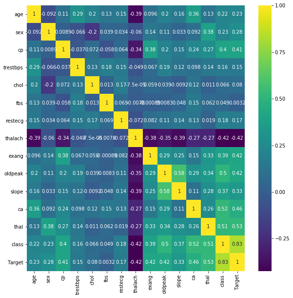

```python
corremat = df.corr()
plt.figure(figsize=(10,10))
g= sns.heatmap(corremat,annot=True,cmap='viridis')
```

On note une corrélation généralement moyenne avec la cible ça serait maldroit de sélectionner des variables explicatives dans ces conditions. Alors nous optons à une réduction de dimension. Mais d'abord répondons à nos questions ci-dessus la corrélation de la cible avec l'âge et le sexe est-elle-le fruit du hasard?

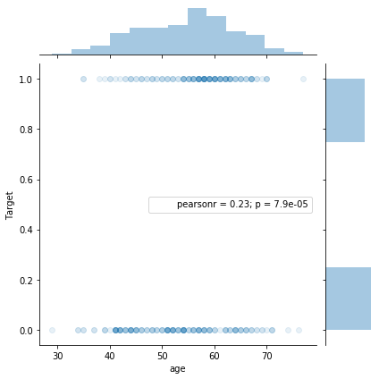

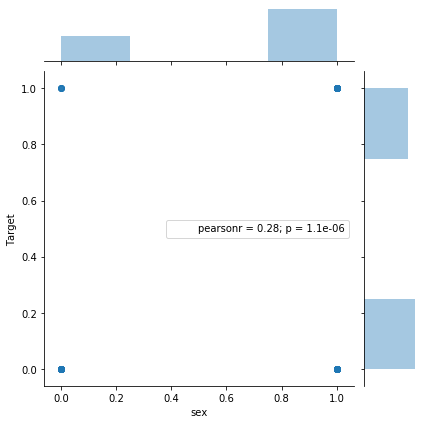

```python
from scipy.stats import pearsonr
sns.jointplot(x='age', y='Target', data=df, alpha = 0.1, stat_func=pearsonr)
sns.jointplot(x='sex', y='Target', data=df, alpha = 0.1, stat_func=pearsonr)
```

Nous obtenons un p inférieur à 0,05 au niveaus des deux variables ('âge et "sex") cela montre qu'il existe bel et bien un lien entre elles et la cible

### Division en train set et test set de la dataset

Nous reservons 20% de la base de donné pour tester notre modèle

```python
X=df[['age', 'sex', 'cp', 'trestbps', 'chol', 'fbs', 'restecg', 'thalach',
       'exang', 'oldpeak', 'slope', 'ca', 'thal']].values
y=df[['Target']].values

from sklearn.model_selection import train_test_split
X_train, X_test, y_train, y_test = \
    train_test_split(X, y, test_size=0.20, random_state=1)
```

## **Construction du model de classification**

Pour la construction du modèle j'ai défini un pipeline constitué de la mise à échelle des données, de la réduction de dimension et du classifieur. Ensuite utilisé GridSearch pour les hyper-parametre

```python
import sklearn.metrics as metrics
from sklearn.metrics import classification_report
from sklearn.metrics import confusion_matrix
from sklearn.metrics import accuracy_score
from sklearn.pipeline import Pipeline
from sklearn.model_selection import GridSearchCV
from sklearn.model_selection import StratifiedKFold
#Importing most common alogorithms
from sklearn.preprocessing import MinMaxScaler
from sklearn.linear_model import LogisticRegression
from sklearn.discriminant_analysis import LinearDiscriminantAnalysis
from sklearn import model_selection #Cross-validation multiple scoring function
import warnings
warnings.simplefilter("ignore")


from pprint import pprint
from time import time
import logging
```

```python
# #############################################################################
# Define a pipeline
# classifier
pipeline = Pipeline([('mms', MinMaxScaler()),
                     ('reduce_dim', LinearDiscriminantAnalysis()),
                     ('classify', LogisticRegression())])

# uncommenting more parameters will give better exploring power but will
# increase processing time in a combinatorial way
parameters = {'classify__penalty': ['l1', 'l2'],
                 'classify__C': [0.05,0.1, 0.3, 0.6, 0.8, 1.0]}

if __name__ == "__main__":
    # multiprocessing requires the fork to happen in a __main__ protected
    # block

    # find the best parameters for both the feature extraction and the
    # classifier
    grid_search = GridSearchCV(pipeline, parameters, n_jobs=-1, verbose=1)

    print("Performing grid search...")
    print("pipeline:", [name for name, _ in pipeline.steps])
    print("parameters:")
    pprint(parameters)
    t0 = time()
    grid_search.fit(X_train, y_train)
    print("done in %0.3fs" % (time() - t0))
    print()

    print("Best score: %0.3f" % grid_search.best_score_)
    print("Best parameters set:")
    best_parameters = grid_search.best_estimator_.get_params()
    for param_name in sorted(parameters.keys()):
        print("\t%s: %r" % (param_name, best_parameters[param_name]))
```

```
Performing grid search...
pipeline: ['mms', 'reduce_dim', 'classify']
parameters:
{'classify__C': [0.05, 0.1, 0.3, 0.6, 0.8, 1.0],
 'classify__penalty': ['l1', 'l2']}
Fitting 5 folds for each of 12 candidates, totalling 60 fits
```

```
[Parallel(n_jobs=-1)]: Using backend LokyBackend with 2 concurrent workers.
```

```
done in 0.953s

Best score: 0.836
Best parameters set:
	classify__C: 0.1
	classify__penalty: 'l2'
```

```
[Parallel(n_jobs=-1)]: Done  60 out of  60 | elapsed:    0.9s finished
```

```python
print('Test Accuracy: %.3f' % grid_search.score(X_test, y_test))
y_pred = grid_search.predict(X_test)
```

```
Test Accuracy: 0.850
```

Notre modèle realise un score de 85% sur les données test

## **Evaluation du modèle**

```python
print(metrics.confusion_matrix(y_test, y_pred))
```

```
[[25  5]
 [ 4 26]]
```

```python
# save confusion matrix and slice into four pieces
confusion = metrics.confusion_matrix(y_test, y_pred)
TP = confusion[1, 1]
TN = confusion[0, 0]
FP = confusion[0, 1]
FN = confusion[1, 0]
```

```python
TP  # 26 vrais positifs
```

```
26
```

```python
TN # 25 vrais négatifs
```

```
25
```

```python
FP # 5 faux positifs
```

```
5
```

```python
FN # 4 faux négatifs
```

```
4
```

**pourcentage de Prediction correcte de notre modèle**

```python
print((TP + TN) / float(TP + TN + FP + FN))
print(metrics.accuracy_score(y_test, y_pred))
```

```
0.85
0.85
```

**pourcentage de Prediction incorrecte de notre modèle**

```python
print((FP + FN) / float(TP + TN + FP + FN))
print(1 - metrics.accuracy_score(y_test, y_pred))
```

```
0.15
0.15000000000000002
```

Sensibilité: lorsque la valeur réelle est positive, à quelle fréquence la prédiction est-elle correcte?

Dans quelle mesure le classificateur est-il "sensible" à la détection d'instances positives? Aussi connu comme "True Positive Rate" ou "Recall

```python
print(TP / float(TP + FN))
print(metrics.recall_score(y_test, y_pred))
```

```
0.8666666666666667
0.8666666666666667
```

Spécificité: lorsque la valeur réelle est négative, à quelle fréquence la prédiction est-elle correcte?

Dans quelle mesure le classificateur est-il «spécifique» (ou «sélectif») pour prédire les cas positifs?

```python
print(TN / float(TN + FP))
```

```
0.8333333333333334
```

La spécificité et la sensibilité sont équilibrées

# **Faisons une nouvelle prédiction**

Les informations suivantes portent sur une femme de 57 ans

> 1. (age):57
> 2. (sex):0
> 3. (cp):4 4.(trestbps):120
> 4. (chol):241
> 5. (fbs):0
> 6. (restecg):2
> 7. (thalach):123
> 8. (exang):1
> 9. (oldpeak):0.2
> 10. (slope):2
> 11. (ca):0.0 13.(thal):7.0

```python
print(grid_search.predict_proba([[57,0,4,120,241,0,2,123,1,0.2,2,0.0,7.0]])[:, 1])
print(grid_search.predict_proba([[57,0,4,120,241,0,2,123,1,0.2,2,0.0,7.0]])[:, 0])
```

```
[0.62734937]
[0.37265063]
```

Notre modèle prédit que cette femme de 57 ans à environ 63% de chance d'être malade et 37% de chance d'être en bonne santé